# Nahrávání a transformace dat

## Procvičení

Zjistěte, jaká byla nejmenší váha kuřete krmeného sójovými boby, jejichž data naleznete v datasetu `chickwts`.

Jaká byla největší hloubka epicentra zemětřesení z datasetu `quakes`, které bylo větší než medián magnitudy všech naměřených zemětřesení?

### Pipes a dobrá praxe

- používejte v jednom scriptu pokud možno jeden typ pipe
- pipe má smysl od tří a výše funkcí
- pokud používáte `%>%` dejte si pozor na záměnu tečky a čárky
- jakmile máte deset a více pipes, tak už by bylo přeci jen dobré si to rozdělit
- pipes jsou lineární; pokud pracujete s více jak jedním výstupem, buď to budete mít krkolomné nebo vám kód vůbec nebude fungovat

# Nahrávání dat

Nahrávání dat je jedna z klíčových znalostí, které je potřeba při práci v R znát.

Stejně jako u indexace, tak i zde existují jak základní příkazy v `baseR`, tak i funkce ve secializovaných balíčcích (k tomu ale později).

**Nastavení working directory**

Před nahráváním dat se ujistěte, že máte nastavenou cestu do adresáře, ze kterého R může čerpat soubory.

**Pokud máte vytvořený R projekt, který se nachází ve stejné složce jako soubory, tato starost vám odpadá.**

## funkce `read.table`

**Základní funkce k načítání tabulkových dat do R.**

Má v sobě několik podtypů pro specifické formáty:

- `read.table` = hodnoty oddělené mezerou
- `read.csv` = hodnoty oddělené čárkou
- `read.delim` = hodnoty oddělené tabulátorem

**Co to znamená, že jsou hodnoty oddělené?**

### Jak má R se souborem pracovat?

Všechny funkce, které nahrávají data do R, v sobě obsahují argumenty, pomocí kterých určujeme, jakým způsobem mají být data načtena.

- `file`: jaký je název souboru? (`"nazev.zkratkaFormatu"`)
- `header`: je první řádek hlavička? (`TRUE / FALSE`)
- `sep`: co odděluje jednotlivé hodnoty? (`" "` `","` `"\t"` `";"`…)
- `dec`: jak určujeme desetinou hodnotu? (`"."` `","` `";"`…)
- a mnoho jiných…

Když můžeme určit separátor, proč existují specifické funkce?

Nahrání zkušebního souboru s určením argumentů:

```r
dataTxt <- read.delim(file = "intro_data.txt",
                       header = TRUE,
                       sep = "", #co je separator
                       dec = ".", #co je desetinna carka
                       na.strings = "NA") #co jsou chybejici hodnoty
```

Nahrání zkušebního souboru bez určení argumentů:

```r
dataTxt2 <- read.delim(file = "intro_data.txt")
```

Jsou tyto dva soubory identické?

```r
identical(dataTxt, dataTxt2)
```

```
[1] TRUE
```

**Nezapomeňte na defaultní nastavení arguentů funkce!**

Spousta funkcí má u argumentů nastavené nějaké defaultní (nejčastěji používané) hodnoty.

Je proto zbytečné argumenty vypisovat znovu, pokud se nijak neliší od defaultního nastavení.

Řešení otázky “proč existují specifické funkce?”

**Protože jsme lenoši.**

### argument `file`

- vždy musí být v uvozovkách a obsahovat přesný název souboru, včetně jeho formátové koncovky
- je potřeba, aby obsahoval **přesný popis cesty** k tomuto souboru
  - Co když máme v projektu dedikovanou **podsložku** na data?

```r
dataUvnitrPodslozkyvProjektu <- read.delim("data/skrytadata.txt")
```

- Co když si potřebujeme vytáhnout **soubor mimo projekt**, a nebo nemáme projekt ani nastavený working directory?

```r
dataBezUrcenehoWD <- read.delim("C:/Users/Lucie Hošková/Desktop/introR_CUNI/materialy/04_transformace/04_prezentace/data/skrytadata.txt")
```

**Absolutní a relativní cesta**

Nepamatujete si, jak přesně se používají relativní / absolutní cesty a projekty? Podívejte se znovu do první lekce, sekce [Working depository](https://luc-hoskova.github.io/introR_CUNI/materialy/01_uvod/01_prezentace/01_prezentace.html#/working-directory) a [RProjekty](https://luc-hoskova.github.io/introR_CUNI/materialy/01_uvod/01_prezentace/01_prezentace.html#/rprojekty).

### argument `sep`

Separátor je symbol či série symbolů, které **určují ohraničení jednotlivých sloupců**.

Jaké máme různé druhy separátorů?

Toto jsou nejčastější typy separátorů, **můžete se ovšem setkat i s jinými individualizovanými separátory**.

Detailněji si tato individualizovaná nastavení ukážeme v následující sekci.

### argument `dec`

Pomocí tohoto argumentu si definujeme symboly, které **určují desetinou čárku**.

Je možné používat jako desetinnou čárku libovolný symbol?

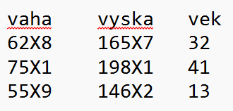

```r
decZkouska <- read.delim("decZkouska.txt", dec = "X")
head(decZkouska)
```

```
  vaha vyska vek
1 62.8 165.7  32
2 75.1 198.1  41
3 55.9 146.2  13
```

## Balíček `readr`

- je součástí metabalíčku `tidyverse`
- umožňuje načtení souboru klikáním v RStudiu **bez psaní kódu**
  - pozor, nefunguje na `.txt` data!

**Postup:**

Vyzkoušíme si to na datech `intro_data.csv`.

[figure not shown]

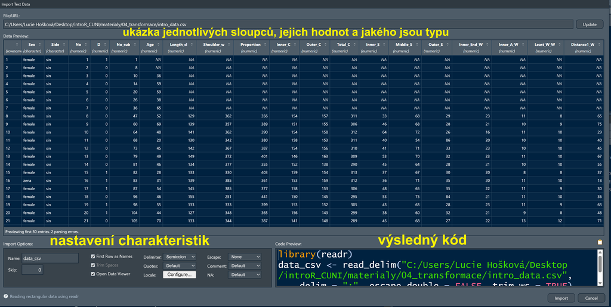

### Dobrá praxe práce s balíčky, které umožňují importování

**Vždy si kód zkopírujte do skriptu a manuálně ho projeďte.**

- import provedete spuštění kódu na pozadí a ve skriptu po něm nezůstane ani stopa, při příštím spuštění samotného skriptu by vám tak nedošlo k načtení dat

**Nezapomeňte si spustit jednotlivé balíčky pomocí fce `library`.**

- není třeba nahrávat celý `tidyverse`, stačí jednoduchý název specifického balíčku

## Balíček `readxl` - ach ty Excely…

- je součástí metabalíčku `tidyverse`

[figure not shown]

Postup je při nahrávání velmi podobný balíčku `readr`, má ovšem **pár důležitých detailů**.

Vyzkoušíme si to na datech `intro_data.xlsx`.

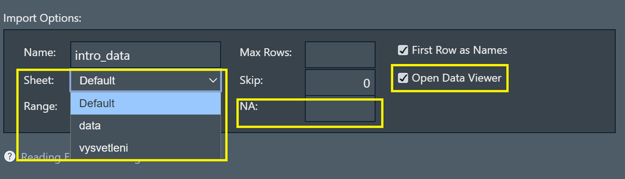

- `Sheet`: z jakého listu chceme vybírat?
- `NA`: narozdíl od `baseR` a `readr` tento balíček neumí automaticky rozpoznávat NA hodnoty
- `Open Data Viewer`: v RStudiu automaticky otevře náhled

## Samostatné cvičení

Načtěte si soubor `samostatneCviceniData.txt` a uložte si ho jako `data`. Přeměňte si sloupec `vzdelani` na faktory<sup>1</sup> a vypočítejte průměrnou výšku ze sloupce `vyska`.

[^1]: Podívejte se do nápovědy; neexistuje na to přímo argument?

### Řešení

Načtěte si soubor `samostatneCviceniData.txt` a uložte si ho jako `data`. Přeměňte si sloupec `vzdelani` na faktory a vypočítejte průměrnou výšku ze sloupce `vyska`.

1. Načteme si soubor pomocí funkce `read.delim` a podíváme se na strukturu.

   ```r
   data <- read.delim("samostatneCviceniData.txt")
   str(data)
   ```

   ```
   'data.frame':   10 obs. of  4 variables:
    $ id      : int  26 981 65 84 563 979 646 634 741 753
    $ vzdelani: chr  "ZS" "VS" "ZS" "SS" ...
    $ vek     : int  45 85 17 23 46 18 23 36 65 47
    $ vyska   : chr  "187,8" "174,5" "168,6" "156,6" ...
   ```

   ```r
   data <- read.delim("samostatneCviceniData.txt",
                      dec = ",")
   str(data)
   ```

   ```
   'data.frame':   10 obs. of  4 variables:
    $ id      : int  26 981 65 84 563 979 646 634 741 753
    $ vzdelani: chr  "ZS" "VS" "ZS" "SS" ...
    $ vek     : int  45 85 17 23 46 18 23 36 65 47
    $ vyska   : num  188 174 169 157 198 ...
   ```

   Nebo můžeme použít funkci, která má přímo určenu desetinnou čárku.

   ```r
   data2 <- read.delim2("samostatneCviceniData.txt")
   str(data2)
   ```

   ```
   'data.frame':   10 obs. of  4 variables:
    $ id      : int  26 981 65 84 563 979 646 634 741 753
    $ vzdelani: chr  "ZS" "VS" "ZS" "SS" ...
    $ vek     : int  45 85 17 23 46 18 23 36 65 47
    $ vyska   : num  188 174 169 157 198 ...
   ```

3. Změňme charakterové stringy (sloupec `vzdelani`) na faktory.

   ```r
   data <- read.delim("samostatneCviceniData.txt",
                      dec = ",",
                      stringsAsFactors = TRUE)
   str(data)
   ```

   ```
   'data.frame':   10 obs. of  4 variables:
    $ id      : int  26 981 65 84 563 979 646 634 741 753
    $ vzdelani: Factor w/ 3 levels "SS","VS","ZS": 3 2 3 1 2 3 1 1 1 1
    $ vek     : int  45 85 17 23 46 18 23 36 65 47
    $ vyska   : num  188 174 169 157 198 ...
   ```

4. Spočítejme si průměrnou výšku.

   ```r
   mean(data$vyska) #175.15
   ```

   ```
   [1] 175.15
   ```

# Transformace dat

Máme nahrána data, co s nimi ted´?

Před tím, než se vrhneme na jakoukoliv analýzu, tak **je třeba si data zkontrolovat a dle potřeby upravit**.

[figure not shown]

## Podivné názvy sloupců

Někdy se může stát, že máte v R dataset, u které jsou jsou **sloupce s totožnými názvy následované čísly a s tečkami mezi slovy**, i když v původním souboru nic takového není.

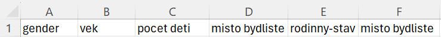

```r
df <- read.delim("bydliste.txt")
head(df)
```

```
  gender vek pocet.deti misto.bydliste rodinny.stav misto.bydliste.1
1      F  19          0         Turnov          N/A       Veselská 5
2      M  85          4        Všenory   manželství        Malá 56/7
3      X  54          2        Karviná  partnerství    U hangáru 898
4      M N/A          3           Zlín     svobodní
5      M  22          0           Most     svobodní
6      F  18          1          Louny          N/A              N/A
```

```r
str(df)
```

```
'data.frame':   15 obs. of  6 variables:
 $ gender          : chr  "F" "M" "X" "M" ...
 $ vek             : chr  "19" "85" "54" "N/A" ...
 $ pocet.deti      : chr  "0" "4" "2" "3" ...
 $ misto.bydliste  : chr  "Turnov" "Všenory" "Karviná" "Zlín" ...
 $ rodinny.stav    : chr  "N/A" "manželství" "partnerství" "svobodní" ...
 $ misto.bydliste.1: chr  "Veselská 5" "Malá 56/7" "U hangáru 898" "" ...
```

Co se to děje?

R automaticky kontroluje, zda **jsou všechny názvy sloupců “validní”**. Provádí se to pomocí defaultního argumentu fce `read.table` a to `check.names = TRUE`.

To znamená, že nemají mezery a **slova jsou oddělena stejným symbolem**, a v **případě duplikátů jmen sloupců** je k nim přiřazen symbol, který je odliší.

Co když se nám ale dané jméno nelíbí? Jak si ho přejmenovat?

```r
df <- df %>%
  dplyr::rename(adresa = misto.bydliste.1)
head(df)
```

```
  gender vek pocet.deti misto.bydliste rodinny.stav        adresa
1      F  19          0         Turnov          N/A    Veselská 5
2      M  85          4        Všenory   manželství     Malá 56/7
3      X  54          2        Karviná  partnerství U hangáru 898
4      M N/A          3           Zlín     svobodní
5      M  22          0           Most     svobodní
6      F  18          1          Louny          N/A           N/A
```

**Přejmenování bez potřeby znát pozici sloupce**

Sice už umíme používat fce `dimnames`, `colnames` a jejich příslušné varianty v argumentech funkcí, i tak se ale hodí znát funkci, která nám **změní specifický sloupec bez toho, abychom museli hledat jeho pořadí** či nějak složitě vypisovat veškerá jména sloupců.

## Chybějící hodnoty

Při kontrole dat jsme si mohli všimnout, že v souboru jsou podivně zapsané chybějící hodnoty - jak prázdná místa, tak text `N/A`.

**Jak toto vše můžeme převést na jednoduchá `NA`?**

```r
dfNA <- read.delim2("bydliste.txt",
                    na.strings = c("", "N/A")) #"" urcuje mezeru/prazdne pole
dfNA
```

```
   gender vek pocet.deti misto.bydliste rodinny.stav      misto.bydliste.1
1       F  19          0         Turnov         <NA>            Veselská 5
2       M  85          4        Všenory   manželství             Malá 56/7
3       X  54          2        Karviná  partnerství         U hangáru 898
4       M  NA          3           Zlín     svobodní                  <NA>
5       M  22          0           Most     svobodní                  <NA>
6       F  18          1          Louny         <NA>                  <NA>
7       F  23          0          Opava     svobodní           Novákové 13
8       F  36          2          Plzeň     svobodní          Destinové 42
9       X  68          3          Jičín   manželství                  <NA>
10      M  47          1        Trutnov  partnerství             Buková 65
11   <NA>  NA         NA           <NA>         <NA>                  <NA>
12      X  33          1          Kuřim         <NA>           U topolu 78
13      M  44          4         Kladno  partnerství           Dolanská 70
14      F 102          0           <NA>     svobodní Břevnovský klášter 76
15      F  76          2           Brno   manželství    Mendlovo náměstí 8
```

**Nejlepším místem je již určení si hodnot při samotném načítání dat argumentem `na.strings`.** Někdy se ale může stát, že si toho všimnete pozdě, a už jste na datasetu provedli rozličné změny.

Jak si tedy můžete tyto hodnoty změnit zpětně?

## Samostatné cvičení

Upravte hodnoty uvnitř data frame `df` tak, aby místo prázdných buněk a charakterové hodnoty `N/A` byly přímo hodnoty `NA`.

**Nezapomeňte na to, co jsme se již naučili**

Na předchozí lekci jsme si ukázali, jakým způsobem lze vybrat z celého data frame specifické hodnoty. Jak bychom to mohli aplikovat zde?

**Přemýšlejte o tom jednoduše - není třeba žádných složitých indexací.**

## Řešení

Upravte hodnoty uvnitř data frame `df` tak, aby místo prázdných buněk a charakterové hodnoty `N/A` byly přímo hodnoty `NA`.

1. Pomocí základní indexace si vybereme všechny hodnoty z `df`, pro které platí `df == "N/A" | df == ""`.

   ```r
   df == "N/A" | df == ""
   ```

   ```
         gender   vek pocet.deti misto.bydliste rodinny.stav adresa
    [1,]  FALSE FALSE      FALSE          FALSE         TRUE  FALSE
    [2,]  FALSE FALSE      FALSE          FALSE        FALSE  FALSE
    [3,]  FALSE FALSE      FALSE          FALSE        FALSE  FALSE
    [4,]  FALSE  TRUE      FALSE          FALSE        FALSE   TRUE
    [5,]  FALSE FALSE      FALSE          FALSE        FALSE   TRUE
    [6,]  FALSE FALSE      FALSE          FALSE         TRUE   TRUE
    [7,]  FALSE FALSE      FALSE          FALSE        FALSE  FALSE
    [8,]  FALSE FALSE      FALSE          FALSE        FALSE  FALSE
    [9,]  FALSE FALSE      FALSE          FALSE        FALSE   TRUE
   [10,]  FALSE FALSE      FALSE          FALSE        FALSE  FALSE
   [11,]   TRUE  TRUE       TRUE           TRUE         TRUE   TRUE
   [12,]  FALSE FALSE      FALSE          FALSE         TRUE  FALSE
   [13,]  FALSE FALSE      FALSE          FALSE        FALSE  FALSE
   [14,]  FALSE FALSE      FALSE           TRUE        FALSE  FALSE
   [15,]  FALSE FALSE      FALSE          FALSE        FALSE  FALSE
   ```

2. Tyto hodnoty si přepíšeme na `NA`

   ```r
   df[df == "N/A" | df == ""] <- NA;
   df
   ```

   ```
      gender  vek pocet.deti misto.bydliste rodinny.stav                adresa
   1       F   19          0         Turnov         <NA>            Veselská 5
   2       M   85          4        Všenory   manželství             Malá 56/7
   3       X   54          2        Karviná  partnerství         U hangáru 898
   4       M <NA>          3           Zlín     svobodní                  <NA>
   5       M   22          0           Most     svobodní                  <NA>
   6       F   18          1          Louny         <NA>                  <NA>
   7       F   23          0          Opava     svobodní           Novákové 13
   8       F   36          2          Plzeň     svobodní          Destinové 42
   9       X   68          3          Jičín   manželství                  <NA>
   10      M   47          1        Trutnov  partnerství             Buková 65
   11   <NA> <NA>       <NA>           <NA>         <NA>                  <NA>
   12      X   33          1          Kuřim         <NA>           U topolu 78
   13      M   44          4         Kladno  partnerství           Dolanská 70
   14      F  102          0           <NA>     svobodní Břevnovský klášter 76
   15      F   76          2           Brno   manželství    Mendlovo náměstí 8
   ```

### Odstranění `NA` hodnot

Dejme ale, že bychom v datasetu chtěli mít pouze kompletní řádky, tzn. chceme se zbavit řádků obsahující `NA` hodnoty. Jak na to?

```r
dim(df)
```

```
[1] 15  6
```

```r
df <- na.omit(df)
dim(df)
```

```
[1] 7 6
```

```r
df
```

```
   gender vek pocet.deti misto.bydliste rodinny.stav             adresa
2       M  85          4        Všenory   manželství          Malá 56/7
3       X  54          2        Karviná  partnerství      U hangáru 898
7       F  23          0          Opava     svobodní        Novákové 13
8       F  36          2          Plzeň     svobodní       Destinové 42
10      M  47          1        Trutnov  partnerství          Buková 65
13      M  44          4         Kladno  partnerství        Dolanská 70
15      F  76          2           Brno   manželství Mendlovo náměstí 8
```

Co se stalo? Zmizely všechny řádky, co měli v jakémkoliv sloupci `NA`. O jaké řádky se ale jednalo?

```r
which(!complete.cases(dfNA))
```

```
[1]  1  4  5  6  9 11 12 14
```

**Dokážete vysvětlit, co se v tomto kombinací těchto funkcí a jejich aplikaci na dataset stane?**

Co dělá funkce `complete.cases` a proč ji zde používáme?

1. **Jako první se podíváme do nápovědy** a zjistíme si, co znamená funkce `complete.cases`.
2. Ta vytvoří vektor, který v sobě bude obsahovat **informace, zda jednotlivé řádky jsou kompletní** - neobsahují žádné chybějící hodnoty.
3. My ovšem chceme vědět, které řádky chybějící hodnoty obsahují - **provedeme proto negaci pomocí symbolu `!`**.
4. A funkce `which` nám pak už pouze řekne, na jaké pozici ve vektoru těchto hodnot se výsledné `TRUE` (řádek obsahuje `NA` hodnoty) nachází.

Máme nyní přejmenované sloupce, odebrané `NA` hodnoty… Znamená to, že s ním nyní můžeme provádět výpočty, či na něj aplikovat jakékoliv další akce?

```r
str(df)
```

```
'data.frame':   7 obs. of  6 variables:
 $ gender        : chr  "M" "X" "F" "F" ...
 $ vek           : chr  "85" "54" "23" "36" ...
 $ pocet.deti    : chr  "4" "2" "0" "2" ...
 $ misto.bydliste: chr  "Všenory" "Karviná" "Opava" "Plzeň" ...
 $ rodinny.stav  : chr  "manželství" "partnerství" "svobodní" "svobodní" ...
 $ adresa        : chr  "Malá 56/7" "U hangáru 898" "Novákové 13" "Destinové 42" ...
 - attr(*, "na.action")= 'omit' Named int [1:8] 1 4 5 6 9 11 12 14
  ..- attr(*, "names")= chr [1:8] "1" "4" "5" "6" ...
```

Jak vidíme, **kvůli špatně zapsaným `NA` hodnotám se nám většina sloupců překonvertovala do charakterového typu**.

Když se ale na data frame podíváme, tak je jasné, že některé sloupce můžeme změnit na faktory a jiné budou jasně numeric.

```r
df
```

```
   gender vek pocet.deti misto.bydliste rodinny.stav             adresa
2       M  85          4        Všenory   manželství          Malá 56/7
3       X  54          2        Karviná  partnerství      U hangáru 898
7       F  23          0          Opava     svobodní        Novákové 13
8       F  36          2          Plzeň     svobodní       Destinové 42
10      M  47          1        Trutnov  partnerství          Buková 65
13      M  44          4         Kladno  partnerství        Dolanská 70
15      F  76          2           Brno   manželství Mendlovo náměstí 8
```

## Funkce `mutate` aneb úprava a vytváření sloupců

Pomocí funkce `mutate` můžeme upravovat specifické sloupce bez dlouhého přiřazování<sup>1</sup>.

Při jejím používání defacto potřebujeme pouze následující zápis:

`mutate(název dataframe, název sloupce = nová podoba sloupce)`

```r
df <- df %>% mutate(
  gender = as.factor(gender),
  vek = as.numeric(vek),
  pocet.deti = as.numeric(pocet.deti),
  rodinny.stav = as.factor(rodinny.stav)
)
```

Jaký je nyní výsledek?

```r
str(df)
```

```
'data.frame':   7 obs. of  6 variables:
 $ gender        : Factor w/ 3 levels "F","M","X": 2 3 1 1 2 2 1
 $ vek           : num  85 54 23 36 47 44 76
 $ pocet.deti    : num  4 2 0 2 1 4 2
 $ misto.bydliste: chr  "Všenory" "Karviná" "Opava" "Plzeň" ...
 $ rodinny.stav  : Factor w/ 3 levels "manželství","partnerství",..: 1 2 3 3 2 2 1
 $ adresa        : chr  "Malá 56/7" "U hangáru 898" "Novákové 13" "Destinové 42" ...
 - attr(*, "na.action")= 'omit' Named int [1:8] 1 4 5 6 9 11 12 14
  ..- attr(*, "names")= chr [1:8] "1" "4" "5" "6" ...
```

[^2]: V sekci Změna specifických hodnot uvnitř data frame si ukážeme, jak je možné pomocí této funkce měnit i jednotlivé hodnoty.

## Přidávání sloupců

Tímto způsobem si ale můžeme sloupce nejenom upravovat, ale i přidávat.

```r
df <- df %>% mutate(
  telefonni.cislo = NA,
  id = paste0("id_", 1:nrow(df)))
head(df)
```

```
   gender vek pocet.deti misto.bydliste rodinny.stav        adresa
2       M  85          4        Všenory   manželství     Malá 56/7
3       X  54          2        Karviná  partnerství U hangáru 898
7       F  23          0          Opava     svobodní   Novákové 13
8       F  36          2          Plzeň     svobodní  Destinové 42
10      M  47          1        Trutnov  partnerství     Buková 65
13      M  44          4         Kladno  partnerství   Dolanská 70
   telefonni.cislo   id
2               NA id_1
3               NA id_2
7               NA id_3
8               NA id_4
10              NA id_5
13              NA id_6
```

## Samostatné cvičení

Proved na souboru `census.csv` následující změny:

## Řešení

1. Načti data a zkontroluj je.

   ```r
   census <- read.csv("census.csv")
   str(census)
   ```

   ```
   'data.frame':   58890 obs. of  19 variables:
    $ idhod       : int  989095533 989113507 989113508 989096570 989112602 989112603 989097795 989116863 989116864 989099080 ...
    $ hodnota     : int  51397 26279 25118 52693 26922 25771 54488 28101 26387 55657 ...
    $ ukaz_kod    : int  3162 3162 3162 3162 3162 3162 3162 3162 3162 3162 ...
    $ vira_cis    : int  3078 3078 3078 3078 3078 3078 3078 3078 3078 3078 ...
    $ vira_kod    : int  1 1 1 1 1 1 1 1 1 1 ...
    $ vira_cleneni: int  1 1 1 1 1 1 1 1 1 1 ...
    $ vek_cis     : int  1035 1035 1035 1035 1035 1035 1035 1035 1035 1035 ...
    $ vek_kod     : int  1000000000 1000000000 1000000000 1000010001 1000010001 1000010001 1000020002 1000020002 1000020002 1000030003 ...
    $ pohlavi_cis : int  NA 102 102 NA 102 102 NA 102 102 NA ...
    $ pohlavi_kod : int  NA 1 2 NA 1 2 NA 1 2 NA ...
    $ uzemi_cis   : int  97 97 97 97 97 97 97 97 97 97 ...
    $ uzemi_kod   : int  19 19 19 19 19 19 19 19 19 19 ...
    $ sldb_rok    : int  2021 2021 2021 2021 2021 2021 2021 2021 2021 2021 ...
    $ sldb_datum  : chr  "2021-03-26" "2021-03-26" "2021-03-26" "2021-03-26" ...
    $ ukaz_txt    : chr  "Počet obyvatel s obvyklým pobytem" "Počet obyvatel s obvyklým pobytem" "Počet obyvatel s obvyklým pobytem" "Počet obyvatel s obvyklým pobytem" ...
    $ vira_txt    : chr  "Bez náboženské víry" "Bez náboženské víry" "Bez náboženské víry" "Bez náboženské víry" ...
    $ vek_txt     : chr  "0 let" "0 let" "0 let" "1 rok" ...
    $ pohlavi_txt : chr  "" "muž" "žena" "" ...
    $ uzemi_txt   : chr  "Česká republika" "Česká republika" "Česká republika" "Česká republika" ...
   ```

2. Přejmenuj sloupce

   ```r
   census <- census %>%
     rename(
       vira = vira_txt,
       pohlavi = pohlavi_txt,
       vek = vek_txt,
       oblast = uzemi_txt)
   ```

3. Přetvoř sloupec `vek` tak, aby obsahoval pouze čísla.

   ```r
   census <- census %>%
     mutate(vek = readr::parse_number(vek))
   ```

4. Vyfiltruj řádky splňující dané podmínky.

   ```r
   census <- census %>%
     filter(
   vira %in% c("Jedi", "Sith") | startsWith(vira, "pasta"),
   pohlavi == "žena",
   vek %in% 0:18 | vek >= 65,
   oblast == "Česká republika")
   ```

5. Vyber relevatní sloupce.

   ```r
   census <- census %>%
     select(hodnota, pohlavi, vek, vira)
   ```

6. Zjisti věk nejstarší Jedi v ČR.

   ```r
   jedi <- census %>% filter(vira == "Jedi",
                             hodnota > 0)
   max(jedi$vek)
   ```

   ```
   [1] 98
   ```

   ```r
   levels(as.factor(census$vira))
   ```

   ```
   [1] "Jedi"            "pastafariánství" "Sith"
   ```

   ```r
   jedi <- census %>% filter(vira == "Jedi", hodnota > 0)
   sith <- census %>% filter(vira == "Sith", hodnota > 0)
   pasta <- census %>% filter(vira == "pastafariánství", hodnota > 0)

   mean(jedi$vek)
   ```

   ```
   [1] 50.02174
   ```

   ```r
   mean(sith$vek)
   ```

   ```
   [1] 14.54545
   ```

   ```r
   mean(pasta$vek)
   ```

   ```
   [1] 32.56667
   ```

A nešlo by to nějak… jednodušeji?

Samozřejmě :]

Vytvoření datasetu na kterém budeme vytvářet výpočty si jde napsat pomocí dlouhé pipe.

```r
census2 <- read.csv("census.csv")
str(census2)
```

```
'data.frame':   58890 obs. of  19 variables:
 $ idhod       : int  989095533 989113507 989113508 989096570 989112602 989112603 989097795 989116863 989116864 989099080 ...
 $ hodnota     : int  51397 26279 25118 52693 26922 25771 54488 28101 26387 55657 ...
 $ ukaz_kod    : int  3162 3162 3162 3162 3162 3162 3162 3162 3162 3162 ...
 $ vira_cis    : int  3078 3078 3078 3078 3078 3078 3078 3078 3078 3078 ...
 $ vira_kod    : int  1 1 1 1 1 1 1 1 1 1 ...
 $ vira_cleneni: int  1 1 1 1 1 1 1 1 1 1 ...
 $ vek_cis     : int  1035 1035 1035 1035 1035 1035 1035 1035 1035 1035 ...
 $ vek_kod     : int  1000000000 1000000000 1000000000 1000010001 1000010001 1000010001 1000020002 1000020002 1000020002 1000030003 ...
 $ pohlavi_cis : int  NA 102 102 NA 102 102 NA 102 102 NA ...
 $ pohlavi_kod : int  NA 1 2 NA 1 2 NA 1 2 NA ...
 $ uzemi_cis   : int  97 97 97 97 97 97 97 97 97 97 ...
 $ uzemi_kod   : int  19 19 19 19 19 19 19 19 19 19 ...
 $ sldb_rok    : int  2021 2021 2021 2021 2021 2021 2021 2021 2021 2021 ...
 $ sldb_datum  : chr  "2021-03-26" "2021-03-26" "2021-03-26" "2021-03-26" ...
 $ ukaz_txt    : chr  "Počet obyvatel s obvyklým pobytem" "Počet obyvatel s obvyklým pobytem" "Počet obyvatel s obvyklým pobytem" "Počet obyvatel s obvyklým pobytem" ...
 $ vira_txt    : chr  "Bez náboženské víry" "Bez náboženské víry" "Bez náboženské víry" "Bez náboženské víry" ...
 $ vek_txt     : chr  "0 let" "0 let" "0 let" "1 rok" ...
 $ pohlavi_txt : chr  "" "muž" "žena" "" ...
 $ uzemi_txt   : chr  "Česká republika" "Česká republika" "Česká republika" "Česká republika" ...
```

```r
census2 <- census2 %>%
  rename(
    vira = vira_txt,
    pohlavi = pohlavi_txt,
    vek = vek_txt,
    oblast = uzemi_txt) %>%
  mutate(vek = readr::parse_number(vek)) %>%
  filter(
    vira %in% c("Jedi", "Sith") | startsWith(vira, "pasta"),
    pohlavi == "žena",
    vek %in% 0:18 | vek >= 65,
    oblast == "Česká republika",
    hodnota > 0) %>%
  select(hodnota, pohlavi, vek, vira)
```

Poté už jen provedeme výpočet jednotlivých hodnot.

```r
census2 %>% group_by(vira) %>%
  summarize(nejstarsiVerici = max(vek), prumernyVek = mean(vek))
```

```
# A tibble: 3 × 3
  vira            nejstarsiVerici prumernyVek
  <chr>                     <dbl>       <dbl>
1 Jedi                         98        50.0
2 Sith                         68        14.5
3 pastafariánství              84        32.6
```

S funkcemi `group_by` a `summarize` se lépe seznámíme v šesté sekci, zde jsou uvedeny jako ukázka zjednodušení postupu.

## Domácí úkol

1. Najděte specifickou funkci v balíčku `dplyr`, která umožňuji přepisování hodnot na `NA`.
2. Načti si dataset [`typBydleni.csv`](https://luc-hoskova.github.io/introR_CUNI/materialy/04_transformace/04_prezentace/typBydleni.csv). Zjisti z něj následující údaje:
   1. Kolik osob ve věku 18-26 včetně v Jihomoravském kraji jsou evidováni jako osoby bez domova, a jakou procentuální část z nich tvoří muži a jakou ženy.
   2. Který kraj má nejmenší počet obyvatel žijících v ubytovacích zařízení?
   3. Jaký je medián věku osoby bez domova v Praze, a jaký je v celé ČR?
   4. Jaký je nejčastější typ ubytování osob pod 18 let v ČR?
   5. O kolik více seniorů (65+ let) bez domova žije v Libereckém než v Moravskoslezském kraji či naopak?

Zdrojem dat jsou [oficiální stránky sčítání obyvatel z roku 2021](https://csu.gov.cz/produkty/vysledky-scitani-2021-otevrena-data). K této tabulce patří i JSON soubor, který popisuje význam jednotlivých sloupců. Můžete ho využít pro lepší pochopení datasetu, ale ke zpracování domácího úkolu nemusíte vyhledávat žádné další informace.

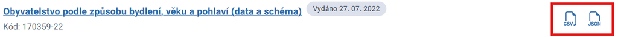

Skript s výpočtem zašlete nejpozději do pátku před příští hodinou na lucie.hoskova@ruk.cuni.cz

## Tipy navíc pro samostudium

### Změna pořadí sloupců

Co kdybychom chtěli mít sloupce na jiné pozici, než jsou v nahraném datasetu?

Použijeme k tomu funkci `dplyr::relocate`.

```r
dfTipy <- read.delim("intro_data.txt",
                     na.strings = c("", "NA"))
dfTipy <- dfTipy[,1:7] #ukazkovy dataset
str(dfTipy)
```

```
'data.frame':   282 obs. of  7 variables:
 $ Sex      : chr  "female" "female" "female" "female" ...
 $ Side     : chr  "sin" "sin" "sin" "sin" ...
 $ No       : int  1 2 3 4 5 6 7 8 9 10 ...
 $ D        : int  1 0 0 0 0 0 0 0 0 0 ...
 $ No_sub   : int  1 8 10 14 20 26 36 47 60 64 ...
 $ Age      : chr  NA NA "36" "59" ...
 $ Length_cl: int  NA NA NA NA NA NA NA 129 139 141 ...
```

```r
dfTipy <- dfTipy %>% relocate(No:No_sub, .before = Sex)
dfTipy <- dfTipy %>% relocate(Sex, .after = Age)
dfTipy <- dfTipy %>% relocate(Side, .after = last_col())
head(dfTipy)
```

```
  No D No_sub  Age    Sex Length_cl Side
1  1 1      1 <NA> female        NA  sin
2  2 0      8 <NA> female        NA  sin
3  3 0     10   36 female        NA  sin
4  4 0     14   59 female        NA  sin
5  5 0     20   59 female        NA  sin
6  6 0     26   38 female        NA  sin
```

### Seřazení řádků dle hodnot ve sloupcích

Může se stát, že si budete potřebovat srovnat podle hodnot v nějakém sloupci. Jak to provedete?

```r
dfTipy %>% arrange(Age) #vzestupne
```

```
    No D No_sub  Age    Sex Length_cl Side
1   58 1    176   18 female       134  sin
2   58 1    176   18 female       132   dx
3   26 1     66   18   male        NA  sin
4   17 1     66   18   male       126   dx
5   28 1    112   19 female       132  sin
6   50 1    153   19 female       142  sin
7   29 1    112   19 female       132   dx
8   50 1    153   19 female       142   dx
9   48 1    102   19   male       158  sin
10  76 1    166   19   male       144  sin
11  37 1    102   19   male       160   dx
12  63 1    166   19   male        NA   dx
13  11 0     68   20 female       130  sin
14   2 0     11   20 female       135   dx
```

[output cut: 268 more lines]

```r
dfTipy %>% arrange(desc(Age)) #sestupne
```

```
    No D No_sub  Age    Sex Length_cl Side
1   38 1     90  old   male       140  sin
2   28 1     90  old   male       140   dy
3   60 1    179   76 female       146  sin
4   61 1    179   76 female       148   dx
5   24 1    108   73 female       139  sin
6   37 1    139   73 female       140  sin
7   25 1    108   73 female       135   dx
8   38 1    139   73 female       139   dx
9   38 1    140   72 female       137  sin
10  39 1    140   72 female       137   dx
11  39 1     91   72   male       157  sin
12  29 1     91   72   male       153   dx
13  54 1    118   71   male       153  sin
14  42 1    118   71   male       154   dx
```

[output cut: 268 more lines]

**Co když ale máme ve sloupci více stejných hodnot?** Můžeme si určit další sloupec, dle kterého by se mělo filtrovat?

Přidáváním dalších a dalších sloupců, dle kterých se může srovnávat, si můžeme vytvořit opravdu podrobně seřazený data frame.

```r
dfTipy %>% arrange(Age, Length_cl)
```

```
    No D No_sub  Age    Sex Length_cl Side
1   17 1     66   18   male       126   dx
2   58 1    176   18 female       132   dx
3   58 1    176   18 female       134  sin
4   26 1     66   18   male        NA  sin
5   28 1    112   19 female       132  sin
6   29 1    112   19 female       132   dx
7   50 1    153   19 female       142  sin
8   50 1    153   19 female       142   dx
9   76 1    166   19   male       144  sin
10  48 1    102   19   male       158  sin
11  37 1    102   19   male       160   dx
12  63 1    166   19   male        NA   dx
13  11 0     68   20 female       130  sin
14   2 0     11   20 female       135   dx
```

[output cut: 268 more lines]

### Načítání velkých souborů

**V balíčku `readr` se nachází taktéž funkce `read_csv`.**

Tu se hodí používat, pokud nahráváte objemnější datasety; běží 2-3x rychleji než `read.csv` v základním R.

### Varianta indexování s pipe

Jedním z míst, kde můžete narazit na potenciální problémy s používání pipe, je indexace.

V sekci Specifikování argumentu kam má pipe vyústit jsme si sice již ukázali, že pomocí placeholderu si **můžeme určit místo vyústění pipe i mimo první argument funkce,** ale nejedná se o úplně nepřehlednější řešení.

```r
dfTipy %>%
  .$No_sub %>%
  head()
```

```
[1]  1  8 10 14 20 26
```

Je možné proto **využít funkce `pull`**.

```r
dfTipy %>%
  pull(No_sub) %>%
  head()
```

```
[1]  1  8 10 14 20 26
```

### Změna specifických hodnot uvnitř data frame

Může se stát, že potřebujeme změnit specifické hodnoty uvnitř data frame podle určitých podmínek. K tomu můžeme použít kombinaci funkcí `mutate` a `replace`.

```r
head(dfTipy)
```

```
  No D No_sub  Age    Sex Length_cl Side
1  1 1      1 <NA> female        NA  sin
2  2 0      8 <NA> female        NA  sin
3  3 0     10   36 female        NA  sin
4  4 0     14   59 female        NA  sin
5  5 0     20   59 female        NA  sin
6  6 0     26   38 female        NA  sin
```

```r
dfTipy <- dfTipy %>%
  mutate(Sex = replace(Sex, Sex == "female", "žena"),
         Age = replace(Age, Age %in% 0:40, "pod 40"))
head(dfTipy)
```

```
  No D No_sub    Age  Sex Length_cl Side
1  1 1      1   <NA> žena        NA  sin
2  2 0      8   <NA> žena        NA  sin
3  3 0     10 pod 40 žena        NA  sin
4  4 0     14     59 žena        NA  sin
5  5 0     20     59 žena        NA  sin
6  6 0     26 pod 40 žena        NA  sin
```

Další možností je funkce `ifelse`.

```r
dfTipy <- dfTipy %>%
  mutate(Side = ifelse(Side == "sin", "leva", "prava"))
head(dfTipy)
```

```
  No D No_sub    Age  Sex Length_cl Side
1  1 1      1   <NA> žena        NA leva
2  2 0      8   <NA> žena        NA leva
3  3 0     10 pod 40 žena        NA leva
4  4 0     14     59 žena        NA leva
5  5 0     20     59 žena        NA leva
6  6 0     26 pod 40 žena        NA leva
```

V obou případech **funkce `mutate` nahrazuje stávající obsah daného sloupce novými hodnotami, které jsou výsledky použitých funkcí**.

### Vyhledávání pomocí specifického textu

Dejme tomu, že pracujete s datasetem ke kterému nemáte mnoho informací, a **chcete zjistit, zda se v něm nachází hodnota obsahující určitý text.**

Přesně k tomuto je určena funkce `grepl`.

Dejme tomu, že chceme zjisti, kolik bouří v datasetu `storms` má jméno obsahující text `"MAR"`.

```r
storms$name[grepl("MAR", toupper(storms$name))] %>% unique()
```

```
[1] "Marco"   "Marilyn" "Maria"   "Omar"    "Martin"  "Margot"
```

Funkce `grepl` zjistí, zda se uvedený text (MAR) nachází v objektu hodnot (hodnoty sloupce `name`).

**Jelikož R je case sensitive, doporučuji vždy vyhledávat pomocí velkých písmen, a převést si na ně i hodnoty, ze kterých se vyhledává.** Pojďme se podívat na to, co by se stalo, kdybychom tak neprovedli.

```r
storms$name[grepl("mar", storms$name)] %>% unique()
```

```
[1] "Omar"
```

Funkce by nám nenašla žádnou z jiných bouří, které tyto písmena obsahují, protože se jedná o jména obsahující písmena “m” “a” “r” v jejich upper case podobě.

```r
#TRUE/FALSE zda hodnota obsahuje "MAR"
grepl("MAR", toupper(storms$name))
```

```
    [1] FALSE FALSE FALSE FALSE FALSE FALSE FALSE FALSE FALSE FALSE FALSE FALSE
   [13] FALSE FALSE FALSE FALSE FALSE FALSE FALSE FALSE FALSE FALSE FALSE FALSE
   [25] FALSE FALSE FALSE FALSE FALSE FALSE FALSE FALSE FALSE FALSE FALSE FALSE
   [37] FALSE FALSE FALSE FALSE FALSE FALSE FALSE FALSE FALSE FALSE FALSE FALSE
   [49] FALSE FALSE FALSE FALSE FALSE FALSE FALSE FALSE FALSE FALSE FALSE FALSE
   [61] FALSE FALSE FALSE FALSE FALSE FALSE FALSE FALSE FALSE FALSE FALSE FALSE
   [73] FALSE FALSE FALSE FALSE FALSE FALSE FALSE FALSE FALSE FALSE FALSE FALSE
   [85] FALSE FALSE FALSE FALSE FALSE FALSE FALSE FALSE FALSE FALSE FALSE FALSE
   [97] FALSE FALSE FALSE FALSE FALSE FALSE FALSE FALSE FALSE FALSE FALSE FALSE
  [109] FALSE FALSE FALSE FALSE FALSE FALSE FALSE FALSE FALSE FALSE FALSE FALSE
  [121] FALSE FALSE FALSE FALSE FALSE FALSE FALSE FALSE FALSE FALSE FALSE FALSE
  [133] FALSE FALSE FALSE FALSE FALSE FALSE FALSE FALSE FALSE FALSE FALSE FALSE
  [145] FALSE FALSE FALSE FALSE FALSE FALSE FALSE FALSE FALSE FALSE FALSE FALSE
  [157] FALSE FALSE FALSE FALSE FALSE FALSE FALSE FALSE FALSE FALSE FALSE FALSE
  [169] FALSE FALSE FALSE FALSE FALSE FALSE FALSE FALSE FALSE FALSE FALSE FALSE
```

[output cut: 1717 more lines]

```r
#vyber hodnoty z name pro ktere je podminka TRUE
storms$name[grepl("MAR", toupper(storms$name))]
```

```
  [1] "Marco"   "Marco"   "Marco"   "Marco"   "Marco"   "Marco"   "Marco"
  [8] "Marco"   "Marco"   "Marco"   "Marco"   "Marco"   "Marco"   "Marco"
 [15] "Marco"   "Marco"   "Marco"   "Marilyn" "Marilyn" "Marilyn" "Marilyn"
 [22] "Marilyn" "Marilyn" "Marilyn" "Marilyn" "Marilyn" "Marilyn" "Marilyn"
 [29] "Marilyn" "Marilyn" "Marilyn" "Marilyn" "Marilyn" "Marilyn" "Marilyn"
 [36] "Marilyn" "Marilyn" "Marilyn" "Marilyn" "Marilyn" "Marilyn" "Marilyn"
 [43] "Marilyn" "Marilyn" "Marilyn" "Marilyn" "Marilyn" "Marilyn" "Marilyn"
 [50] "Marilyn" "Marilyn" "Marilyn" "Marilyn" "Marilyn" "Marilyn" "Marilyn"
 [57] "Marilyn" "Marilyn" "Marilyn" "Marilyn" "Marilyn" "Marilyn" "Marilyn"
 [64] "Marilyn" "Marilyn" "Marilyn" "Marilyn" "Marilyn" "Marilyn" "Marilyn"
 [71] "Marilyn" "Marilyn" "Marilyn" "Marilyn" "Marilyn" "Marilyn" "Marilyn"
 [78] "Marilyn" "Marilyn" "Marilyn" "Marilyn" "Marilyn" "Marilyn" "Marilyn"
 [85] "Marilyn" "Marilyn" "Marilyn" "Marilyn" "Marilyn" "Marilyn" "Marilyn"
 [92] "Marilyn" "Marilyn" "Marilyn" "Marilyn" "Marilyn" "Marco"   "Marco"
 [99] "Marco"   "Marco"   "Marco"   "Marco"   "Marco"   "Marco"   "Marco"
```

[output cut: 52 more lines]

```r
storms$name[grepl("MAR", toupper(storms$name))] %>%
  unique() #kazde jmeno jen jednou
```

```
[1] "Marco"   "Marilyn" "Maria"   "Omar"    "Martin"  "Margot"
```